# First Glances: PASS urine biomarkers

Marshall Brown  
3/20/2015

### Introduction

A first look at the urine biomarker data where I summarize the data using descriptive statistics, provide simple visualizations of measurements over time, and apply some first steps to modeling biomarker values.

### Sample sizes

Values are shown for data where biomarker information is known (and for the full data).

- Number of participants: 1080 (1087)
- Total number of measurements: 2745 (2819)
  - 57 individuals with one or more missing measurements.

### Number of measurements per individual

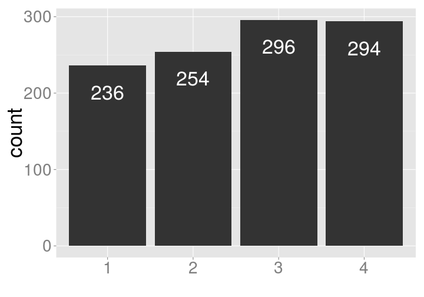

### Measurements by time since enrollment

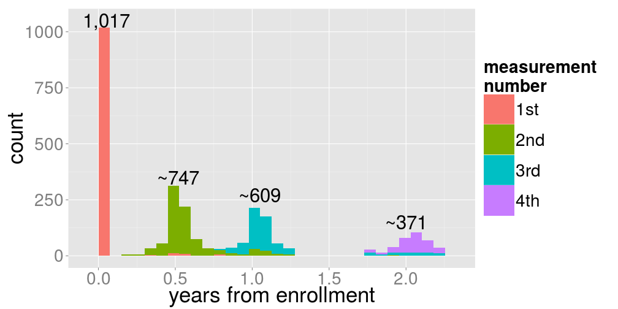

- values printed on figure indicate how many measurements within each 'mound'

### Measurements by time since diagnosis

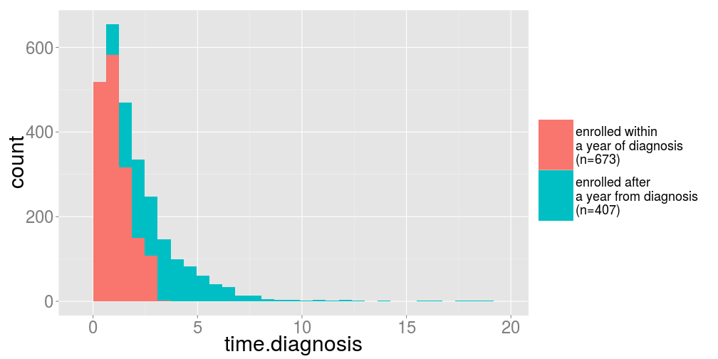

### Variables of interest

- Biomarkers (outcome)
  - PCA3 Score
  - TMPRSS2:ERG Score
- Time (since diagnosis)
- Other covariates
  - Age
  - Batch
  - Site

### Variables of interest (Biomarkers)

- PCA3 Score

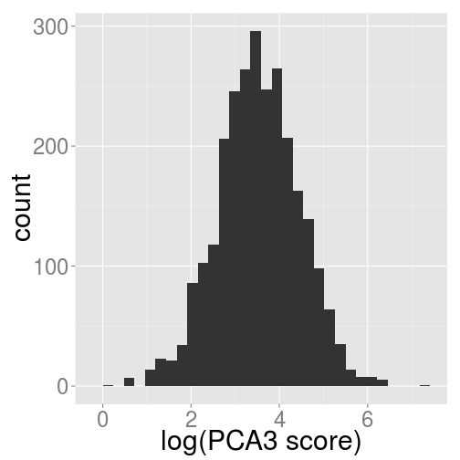

- TMPRSS2:ERG Score

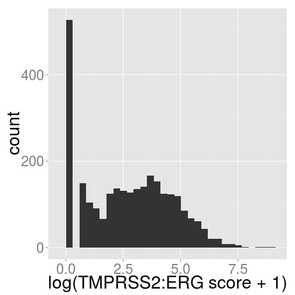

### Variables of interest (Age)

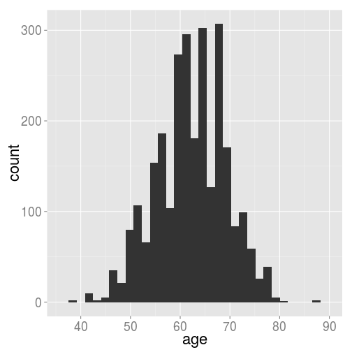

| Min. | 1st Qu. | Median | 3rd Qu. | Max. |
| --- | --- | --- | --- | --- |
| 39 | 58 | 63 | 67 | 88 |

### Variables of interest (batch and site)

- Batch (10 batches)

| 1 | 2 | 2013-04 | 2013-12 | 2014-12 | 3 | 4 | 5 | 6 | 7 |
| --- | --- | --- | --- | --- | --- | --- | --- | --- | --- |
| 121 | 124 | 265 | 312 | 1299 | 83 | 59 | 93 | 102 | 287 |

- Site (9 sites)

| 88 | 142 | 203 | 424 | 426 | 428 | 441 | 510 | 545 |
| --- | --- | --- | --- | --- | --- | --- | --- | --- |
| 401 | 627 | 235 | 216 | 562 | 290 | 182 | 118 | 114 |

### Question

1. How do biomarker values vary through time?
2. should we account for age effects?
   - batch effects?
   - site effects?
3. how do we best model biomarker variation?

### Question

1. **How do biomarker values vary through time?**
2. should we account for age effects?
   - batch effects?
   - site effects?
3. how do we best model biomarker variation?

### PCA3 by diagnosis time

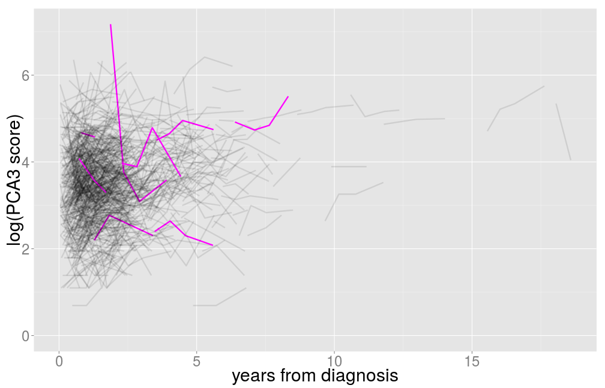

### TMPRSS2:ERG by diagnosis time

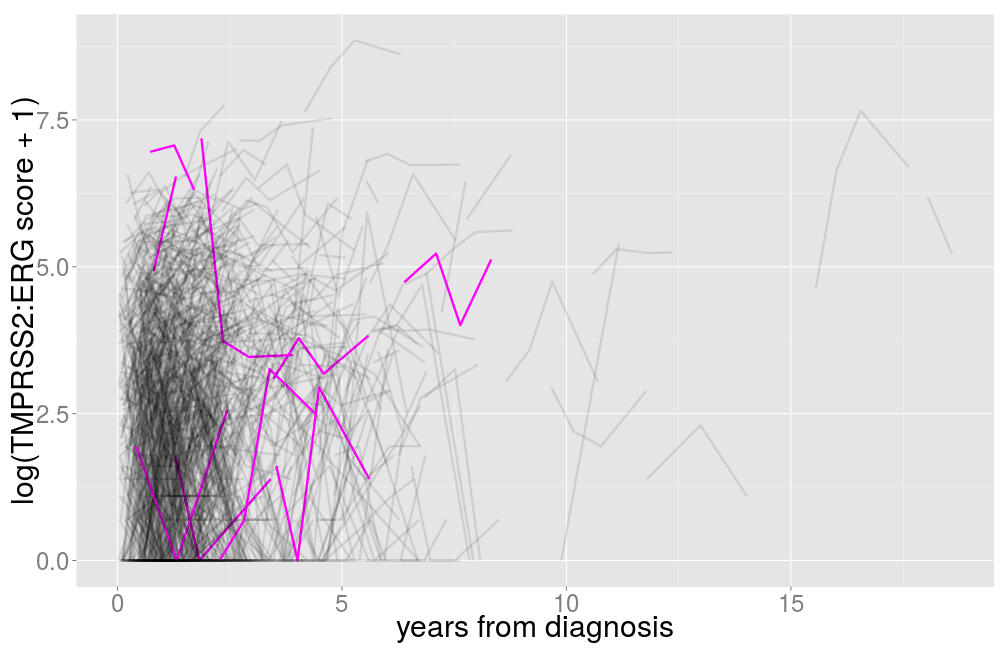

### Question

1. How do biomarker values vary through time?
2. **should we account for age effects?**
   - batch effects? (see end slides)
   - site effects? (see end slides)
3. how do we best model biomarker variation?

### Biomarker value by age

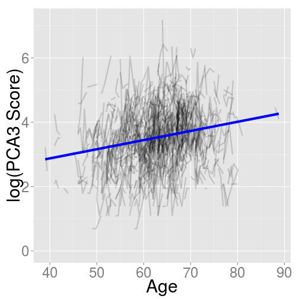

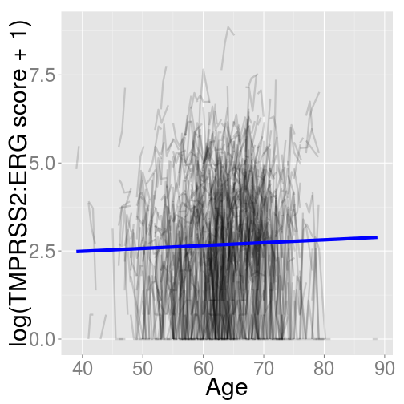

### Question

1. How do biomarker values vary through time?
2. should we account for age effects?
   - batch effects? (see end slides)
   - site effects? (see end slides)
3. **how do we best model biomarker variation?**

### Mixed effect models

- **fixed effects**:
  - Time since diagnosis *(non-linear)*
  - Age
- **random effects**
  - individual
  - Factor indicating whether measurements were taken within a year from diagnosis vs greater than a year from diagnosis**
  - random slope for age**

*compare the expanded models to simpler models using ANOVA*

- *Simpler models fit the data better.*

### Mixed effect models: PCA3

- *Marginal* \( R^2 \): **0.07** *Conditional* \( R^2 \): **0.85**
- **fixed**: age, *(non-linear)* time from diagnosis

|  | Value | Std.Error | p-value |
| --- | --- | --- | --- |
| **(Intercept)** | 1.5 | 0.24 | <0.001 |
| **age** | 0.03 | 0.004 | <0.001 |
| **ns(time)'** | 0.5 | 0.11 | <0.001 |
| **ns(time)''** | 1.4 | 0.23 | <0.001 |
| **ns(time)'''** | 1.7 | 0.46 | <.0001 |

- **random**: individual effect

```
        (Intercept)  Residual
StdDev:   0.822       0.368
```

### PCA3

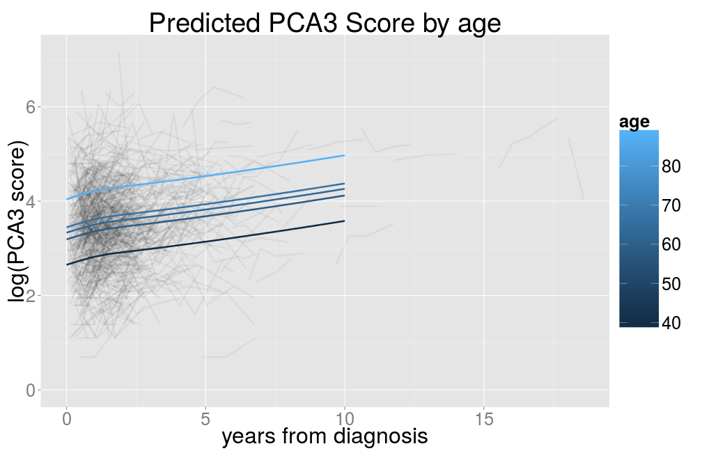

population level predicted score by age and years from diagnosis.

### PCA3

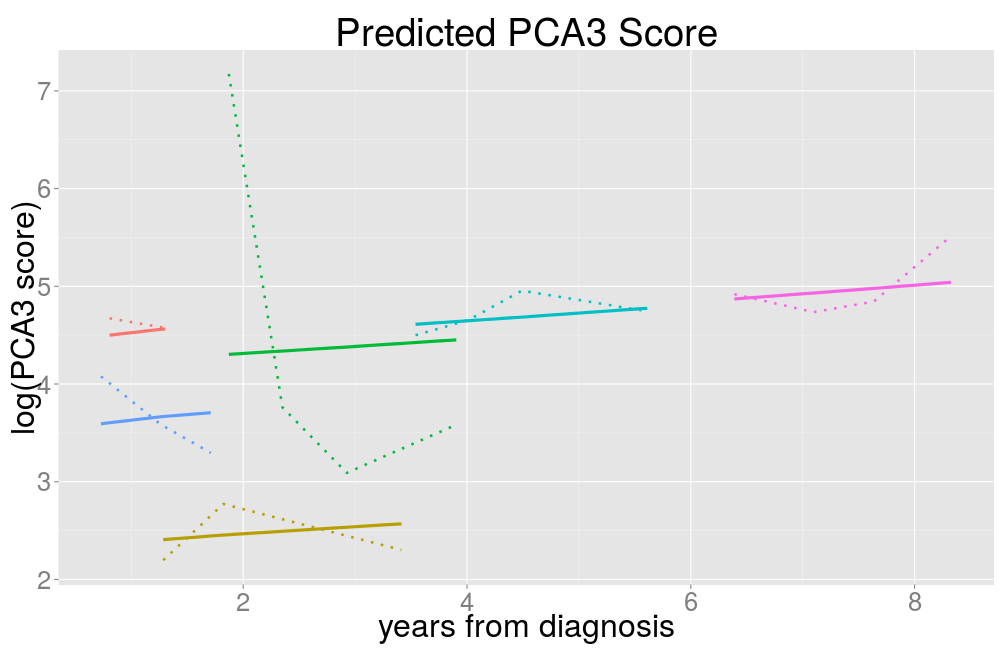

individual level predictions (solid line) by age and years from diagnosis. Observed trajectories shown by dotted line.

### Mixed effect models: TMPRSS2:ERG score

- *Marginal* \( R^2 \): **0.01** *Conditional* \( R^2 \): **0.69**
- **fixed**: *(non-linear)* time from diagnosis

|  | Value | Std.Error | p-value |
| --- | --- | --- | --- |
| **(Intercept)** | 2.5 | 0.07455 | <0.001 |
| **ns(time)'** | 1.9 | 0.44 | <0.001 |
| **ns(time)''** | 2.4 | 0.96 | 0.014 |

- **random**: individual effect

```
          (Intercept) Residual
StdDev:    1.58       1.07
```

### TMPRSS2:ERG score

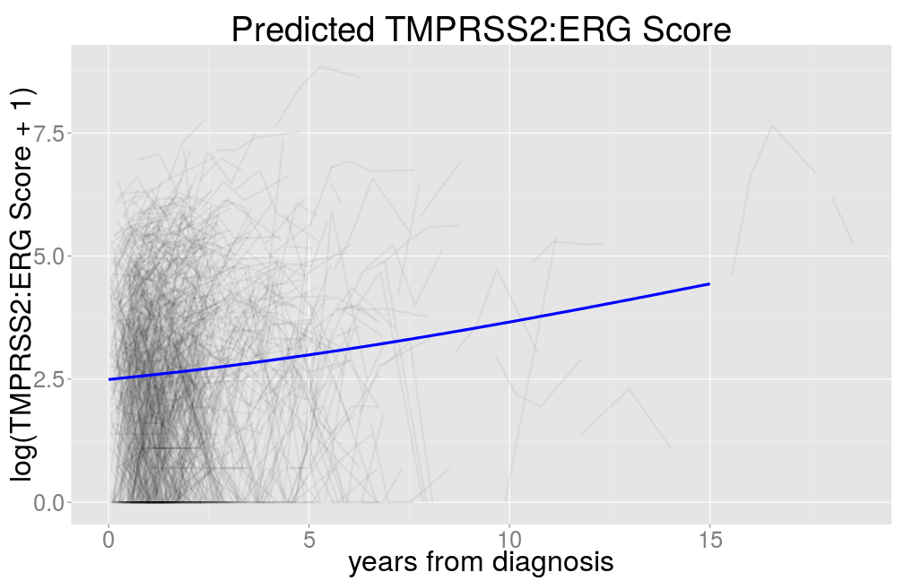

population level predicted score by years from diagnosis.

### TMPRSS2:ERG score

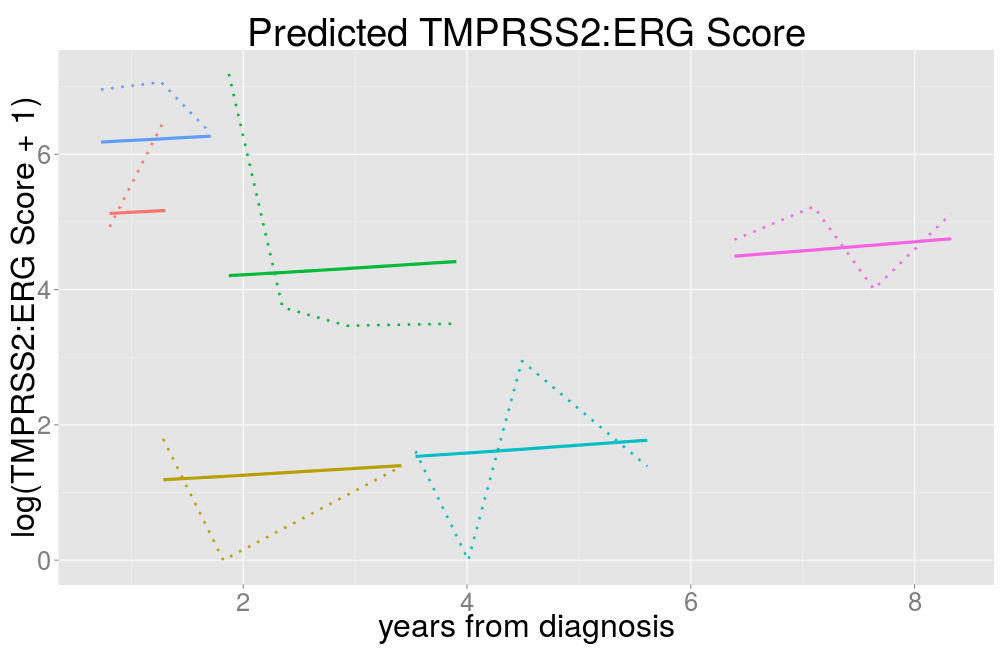

individual level predictions (solid line) by years from diagnosis. Observed trajectories shown by dotted line.

### Modelling summary

- Fixed effects are not good at explaining variation.
  - time from diagnosis is associated with both biomarkers.
  - age is associated with PCA3 but not TMPRSS2:ERG.
- lots of individual level variation.

|  | PCA3 | TMPRSS2:ERG |
| --- | --- | --- |
| marginal \( R^2 \) | 0.07 | 0.01 |
| conditional \( R^2 \) | 0.85 | 0.69 |

- simpler models are better
- more work to be done to determine if there are batch/site effects.
- need to spend more time checking mixed model assumptions.

### Batch Effects

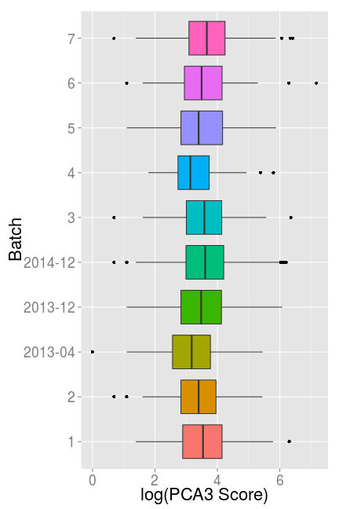

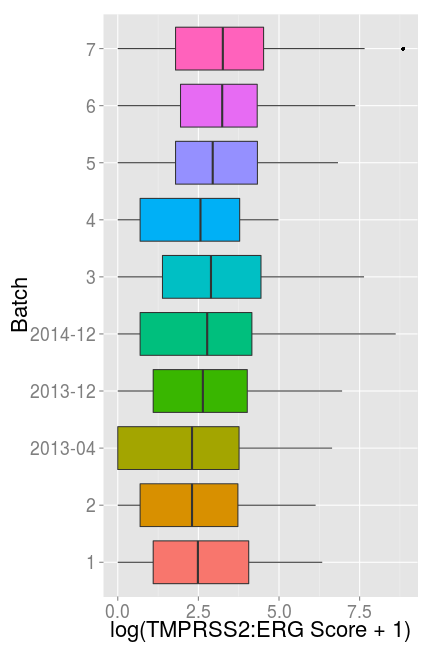

### Site Effects

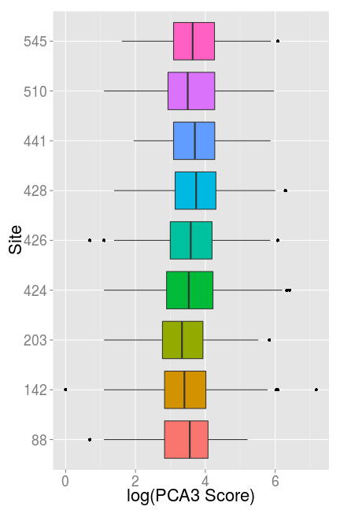

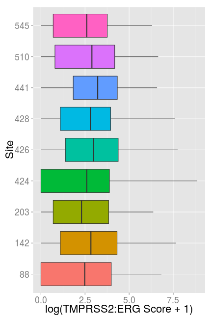